# Администрирование системных подсистем

Настройка SMTP, LMTP, SASL и TLS на Postfix + Dovecot

Сейдалиев Тагиетдин Ровшенович

Российский университет дружбы народов, Москва, Россия

30 ноября 2025

# Цель работы

## Основная цель

Получение практических навыков настройки SMTP-сервера Postfix и Dovecot: LMTP, аутентификация SASL, TLS-шифрование.

# Настройка LMTP в Dovecot

## Добавление поддержки LMTP

Добавляем LMTP в конфигурацию Dovecot.

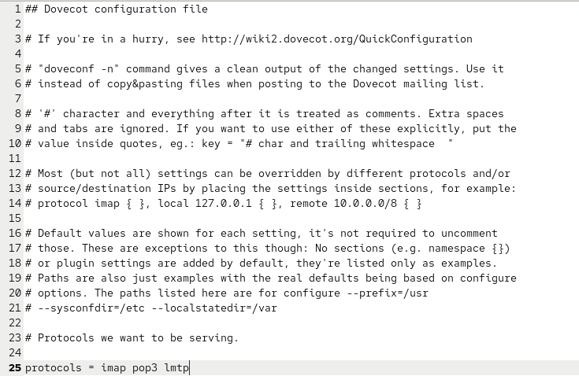

LMTP протокол

## Настройка LMTP-сервиса

Определяем сокет LMTP для взаимодействия Postfix и Dovecot.

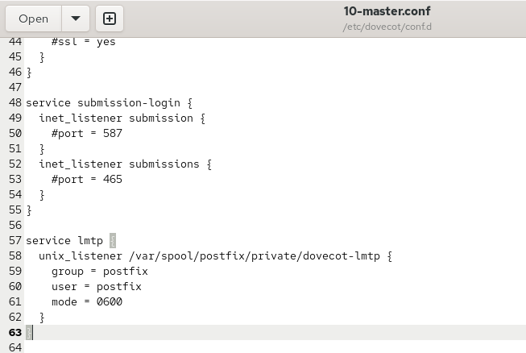

Сервис LMTP

## Формат имени пользователя

Задаём формат логина без доменной части.

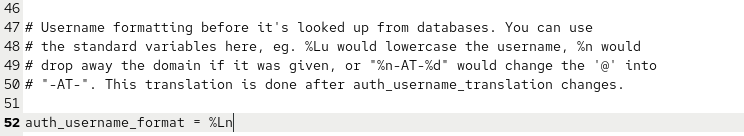

auth_username_format

## Логи успешной LMTP-доставки

Подтверждение доставки письма в INBOX через LMTP.

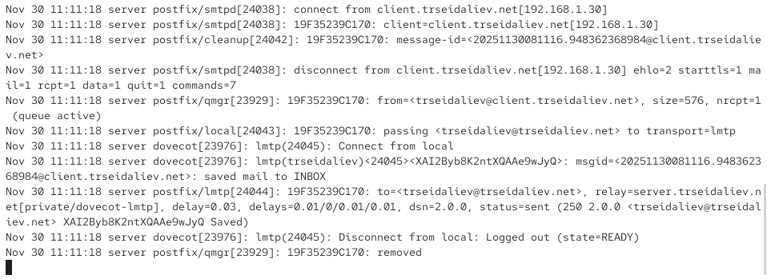

Логи LMTP

## Проверка Maildir

Письмо отображается в пользовательском почтовом ящике.

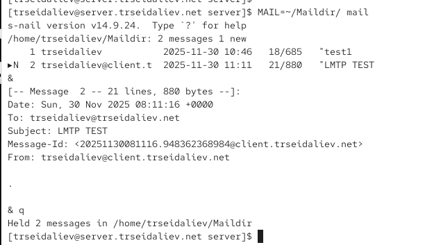

Maildir

# Настройка SMTP-аутентификации

## Служба auth в Dovecot

Настраивается сокет для SASL-аутентификации Postfix.

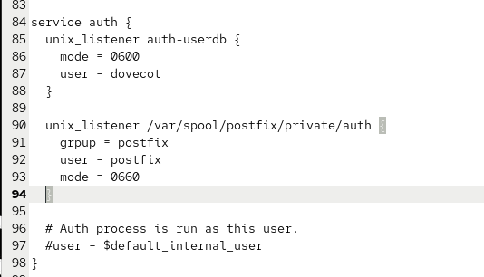

auth service

## Включение SASL в Postfix

Postfix использует Dovecot как механизм SASL.

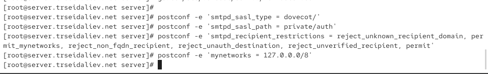

postconf sasl

## Ограничения приёма писем

Настраиваются правила защиты от open relay.

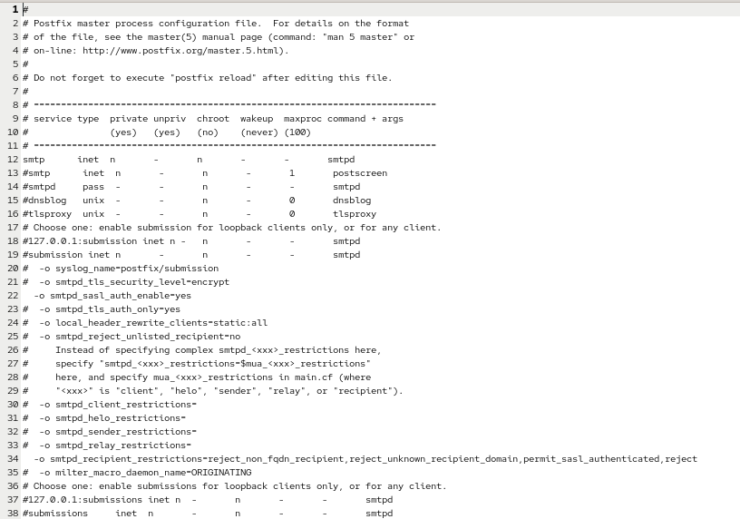

master.cf

## Проверка аутентификации

Пользователь успешно проходит SMTP AUTH.

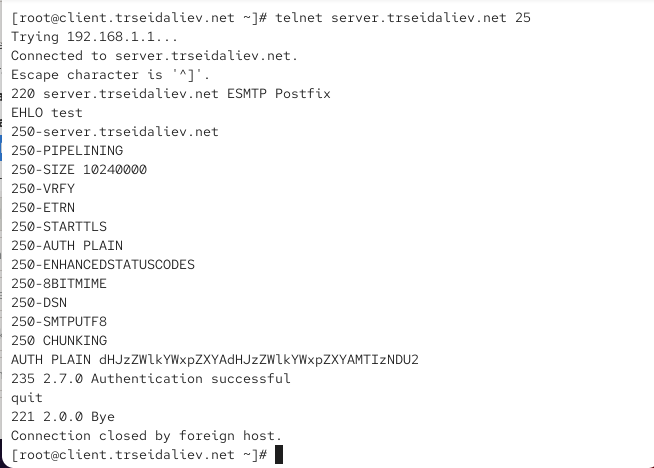

telnet auth

# Настройка SMTP over TLS

## TLS-конфигурация Postfix

Postfix использует сертификаты Dovecot для TLS.

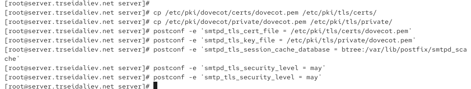

TLS настройка

## Служба submission на порту 587

Создаётся защищённый SMTP-сервис с обязательным шифрованием.

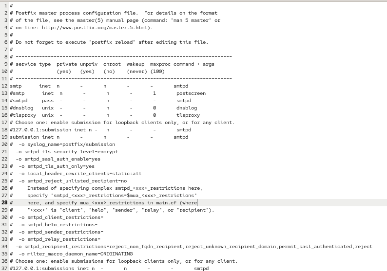

submission

## STARTTLS через openssl

Проверяется установление TLS-сессии и успешный AUTH.

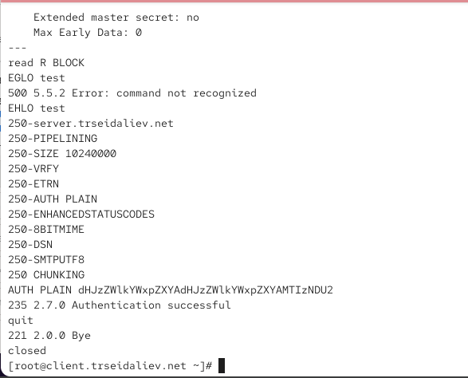

openssl test

## Настройка SMTP в Evolution

Почтовый клиент успешно использует порт 587 и STARTTLS.

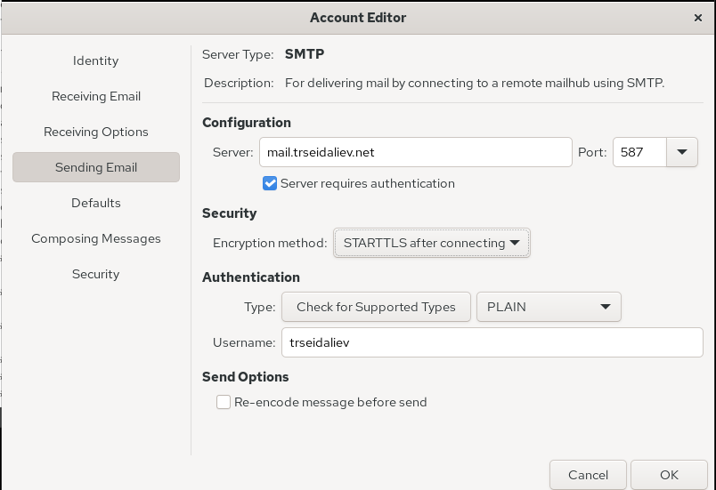

evolution smtp

## Проверка доставки писем

Письма успешно доставляются через защищённый SMTP.

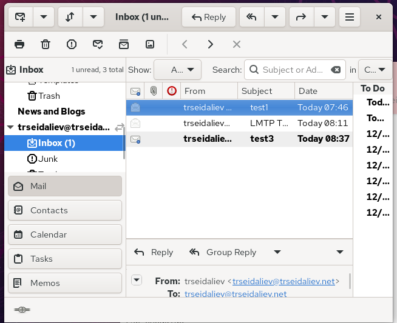

Почтовый клиент

## Логи Postfix и Dovecot

Журнал фиксирует успешную обработку и доставку писем.

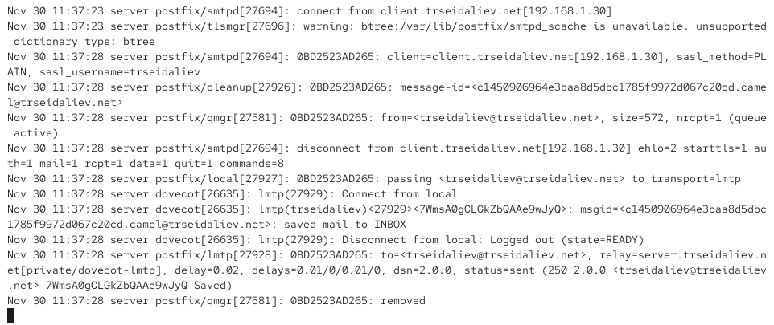

maillog

# Заключение

В ходе выполнения работы:

- настроен SMTP-сервер Postfix с поддержкой аутентификации пользователей через Dovecot;
- реализована передача почты посредством LMTP-сервиса Dovecot;
- включена и проверена работа TLS-шифрования для SMTP (порт 587, STARTTLS);
- выполнена настройка firewall для служб smtp и smtp-submission;
- протестирована SMTP-аутентификация как через telnet/openssl, так и через почтовый клиент Evolution;
- обновлены конфигурации Postfix и Dovecot в каталоге provisioning для автоматизации развёртывания.